# Introduction to DPDdataextractor3

The DPDataExtractor3 package was developed for the processing of the Government of Canada’s Drug Product Database (DPD) files. A modularized and object-oriented design was adopted not only to ensure the greatest possible flexibility in terms of the formats of the tables that can be generated in relation to the number, identity and order of the columns, but also to facilitate completely different future developments of this tool within the field of drug utilization statistics. Although the emphasis was put for this version of the package on the processing of information related to antibiotics, it could be used for any drug.

```r
library(DPDextractor3)
```

These 14 global functions use directly or undirectly DPDextractor methods: AntibSalesReader(), AntibSalesStats(), DataFromZipfiles(). CFmergeFiles2(), FileMerge() and HVmerge(), datasetVTransmerge(), datasetVmerge(), addActivity(), AddMergedIngredNames(), AddMergedIngredNames2(), addExtraVetcols(), addCategory(), and kdataset().

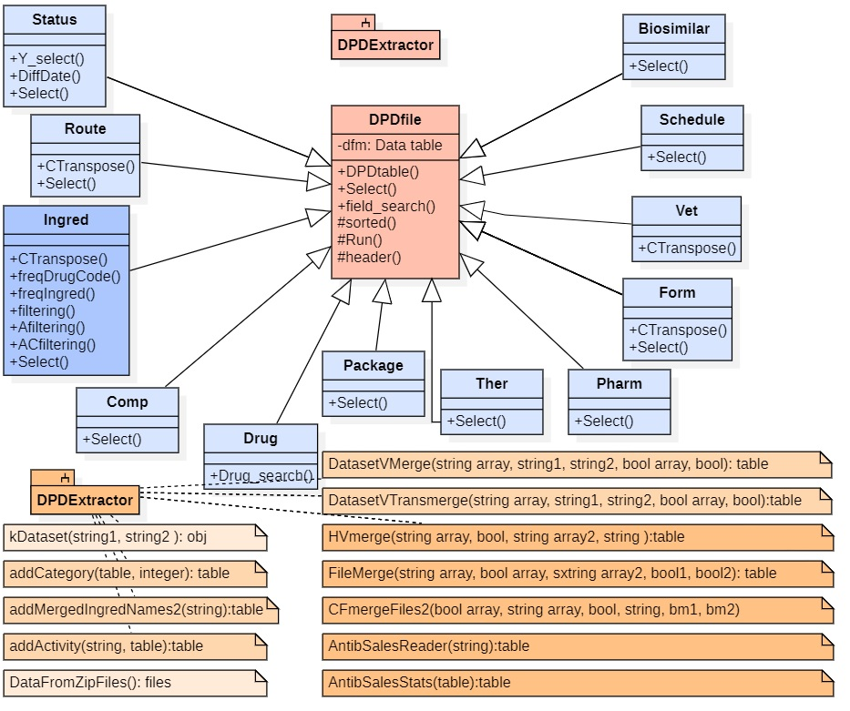

Package diagram

Below are some examples of how to use the package. We show some use cases of high level functions and finish with examples of how some DPDextractor methods are used

## Examples of the use of high-level functions:DataFromZipfiles(), CFmergeFiles2() y FileMerge()

```
---
DataFromZipfiles()
CFmergeFiles2()
---
```

The DataFromZipfiles()function downloads and unzips the DPD files. Therefore, all global functions of the package require the prior execution of this function.CFmergeFiles2()is a pipeline that concatenates the execution of several functions, each of which performs the merging of the rows corresponding to the approved, marketed, dormant and cancelled drugs for all the DPD tables. Two functions, datasetVTransmerge() and datasetVmerge(), are mainly used in this pipeline for merging and selective transposition of tables. The first function can perform two types of transposition, For the first type, all different values are transformed into columns or variables, and for the second type, the maximum number of values assigned to the same drug code is transformed into columns or variables.

```
---
DataFromZipfiles()

CFmergeFiles2(fout="superTabIngDrugrouteformCompStaVetPack_CF1.csv", bm1=0, bm2=0, extrac=TRUE)
CFmergeFiles2(fout="superTabIngDrugrouteformCompStaVetPack_CF3.csv", bm1=1, bm2=1, extrac=FALSE)
CFmergeFiles2(fout="superTabIngDrugrouteformCompStaVetPack_CF4.csv", bm1=2, bm2=2, extrac=TRUE)

---
```

Another function such as FileMerge() generates separate csv files from each of the DPD tables. Other functions such as ddActivity(), AddMergedIngredNames2(), addExtraVetcols() and addCategory() incorporate in the generated tables, fields not found in the DPD database.

```
---
txt_files <- list.files(path = getwd(), pattern = "txt")

FileMerge(txt_files)
FileMerge(txt_files, b=c(0,0,0,0))
FileMerge(txt_files, b=c(1,1,0,1))
FileMerge(txt_files, b=c(1,1,1,1))
FileMerge(txt_files, b=c(0,0,1,1),  dpdlabel=c("ingred", "form", "route","vet"))
FileMerge(txt_files, b=c(0,0,0,0), dpdlabel=c("drug","status", "route", "form", "comp","ingred", "package", "vet"), filt=FALSE, outf=TRUE)
---
```

## Examples of the use of functions: datasetVTransmerge(), datasetVmerge(), addMergedIngredNames2, addCategory()y addActivity()

```
---
txt_files <- list.files(path = getwd(), pattern = "txt")

ing<-datasetVTransmerge(txt_files, dpdlabel="ingred")
write.csv(ing, "D:/WIAAgrosante/Mapaq-Antibioticos/DPDataExtractor/transTabIA.csv", row.names=FALSE)

ingtf<-datasetVTransmerge(txt_files, dpdlabel="ingred",f="listAntibiodine.txt", stat=c(1, 1, 1, 1), filt=TRUE)
write.csv(ingtf, "D:/WIAAgrosante/Mapaq-Antibioticos/DPDataExtractor/transTabIAtf.csv", row.names=FALSE)

ingf<-datasetVmerge(txt_files, dpdlabel="ingred")
write.csv(ingf, "D:/WIAAgrosante/Mapaq-Antibioticos/DPDataExtractor/TabIA.csv", row.names=FALSE)

sta<-datasetVmerge(txt_files, dpdlabel="status")
write.csv(sta, "D:/WIAAgrosante/Mapaq-Antibioticos/DPDataExtractor/TabStatus.csv", row.names=FALSE)

drug<-datasetVmerge(txt_files, dpdlabel="drug")
write.csv(drug, "D:/WIAAgrosante/Mapaq-Antibioticos/DPDataExtractor/TabDrug.csv", row.names=FALSE)

pack<-datasetVmerge(txt_files, dpdlabel="package")
write.csv(pack, "D:/WIAAgrosante/Mapaq-Antibioticos/DPDataExtractor/TabPack.csv", row.names=FALSE)

route<-datasetVmerge(txt_files, dpdlabel="route")
write.csv(route, "D:/WIAAgrosante/Mapaq-Antibioticos/DPDataExtractor/TabRoute.csv", row.names=FALSE)

transroute<-datasetVmerge(txt_files, dpdlabel="route")
write.csv(transroute, "D:/WIAAgrosante/Mapaq-Antibioticos/DPDataExtractor/transTabRoute.csv", row.names=FALSE)

form<-datasetVmerge(txt_files, dpdlabel="form")
write.csv(form, "D:/WIAAgrosante/Mapaq-Antibioticos/DPDataExtractor/TabForm.csv", row.names=FALSE)

com<-datasetVmerge(txt_files, dpdlabel="comp")
write.csv(com, "D:/WIAAgrosante/Mapaq-Antibioticos/DPDataExtractor/TabCom.csv", row.names=FALSE)

pack<-datasetVmerge(txt_files, dpdlabel="package")
write.csv(pack, "D:/WIAAgrosante/Mapaq-Antibioticos/DPDataExtractor/TabPack.csv", row.names=FALSE)

the<-datasetVmerge(txt_files, dpdlabel="ther")
write.csv(the, "D:/WIAAgrosante/Mapaq-Antibioticos/DPDataExtractor/TabTher.csv", row.names=FALSE)

transve<-datasetVTransmerge(txt_files, dpdlabel="vet")
```

[output cut: 39 more lines]

```
tab <- merge(tab,tab2,by="DRUG_CODE", all.tab=T)
tab[,'DRUG_CODE']<- as.character(tab[,'DRUG_CODE'])
write.csv(tab, "D:/WIAAgrosante/Mapaq-Antibioticos/DPDataExtractor/superTab4.csv", row.names=FALSE)

tab2<-read.csv("D:/WIAAgrosante/Mapaq-Antibioticos/DPDataExtractor/TabPack.csv", header=TRUE, stringsAsFactors=FALSE)
tab <- merge(tab,tab2,by="DRUG_CODE", all=T)
tab[,'DRUG_CODE']<- as.character(tab[,'DRUG_CODE'])
write.csv(tab, "D:/WIAAgrosante/Mapaq-Antibioticos/DPDataExtractor/superTab5.csv", row.names=FALSE)

tab2<-read.csv("D:/WIAAgrosante/Mapaq-Antibioticos/DPDataExtractor/transTabVet.csv", header=TRUE, stringsAsFactors=FALSE)
tab <- merge(tab,tab2,by="DRUG_CODE", all=T)
tab[,'DRUG_CODE']<- as.character(tab[,'DRUG_CODE'])
tab<-tab[!is.na(tab$CLASS),]
write.csv(tab, "D:/WIAAgrosante/Mapaq-Antibioticos/DPDataExtractor/superTabtrouteformPack0.csv", row.names=FALSE)
---
```

## Examples of the use of various methods of DPDextractor classes:

```
---
 path<-getwd()
 dir<-paste0(path,"/", "route.txt")

obj1<-DPDfile$new(dir)
obj1$DPDtable

obj1$field_search("DRUG", TRUE)
obj1$field_search("PRODUCT")

---
 path<-getwd()
 dir<-paste0(path,"/", "vet.txt")

 obj2<-vet$new(dir)
 obj2$select()

 Tab2<-obj2$DPDtable
 transTab2<-obj2$CTranspose()

  dir2<-paste0(path,"/", "Tab_vet_Marketed.csv")

  dir3<-paste0(path,"/", "transTab_vet_Marketed.csv")

  write.csv(Tab2, dir2, row.names=FALSE)

 write.csv(transTab2, dir3, row.names=FALSE)

---

  path<-getwd()
  dir<-paste0(path,"/", "route.txt")

  obj3<-route$new(dir)

  Tab<-obj3$DPDtable
  transTab<-obj3$CTranspose()

  dir2<-paste0(path,"/", "Tab_route_Marketed.csv")

```

[output cut: 48 more lines]

```
obj3$select()
Tab3<-obj3$DPDtable
dir3<-paste0(path,"/", "df_status_Marketed.csv")

write.csv(Tab3, dir3, row.names=FALSE)


---

obj1<-DPDfile$new("D:/WIAAgrosante/Mapaq-Antibioticos/DPD/route.txt")
obj1$DPDtable
obj1$field_search("DRUG", TRUE)
obj1$field_search("PRODUCT")

---
```